# Helmnet

```python
import tensorflow as tf
print("Num GPUs Available:", len(tf.config.list_physical_devices('GPU')))
print(tf.__version__)
```

```
Num GPUs Available: 1
2.17.1
```

```python
import os
import random
import numpy as np
import pandas as pd
import seaborn as sns
import matplotlib.image as mpimg
import matplotlib.pyplot as plt
import math
import cv2
```

```python
# Tensorflow modules
import keras
import tensorflow as tf
from tensorflow.keras.preprocessing.image import ImageDataGenerator
from tensorflow.keras.models import Sequential
from tensorflow.keras.layers import Dense,Dropout,Flatten,Conv2D,MaxPooling2D,BatchNormalization
from tensorflow.keras.optimizers import Adam,SGD
from sklearn import preprocessing
from sklearn.model_selection import train_test_split
from sklearn.metrics import confusion_matrix
from tensorflow.keras.models import Model
from keras.applications.vgg16 import VGG16
```

```python
# Display images using OpenCV
from google.colab.patches import cv2_imshow

#Imports functions for evaluating the performance of machine learning models
from sklearn.metrics import confusion_matrix, f1_score,accuracy_score, recall_score, precision_score, classification_report
from sklearn.metrics import mean_squared_error as mse
# Ignore warnings
import warnings
warnings.filterwarnings('ignore')
```

```python
tf.keras.utils.set_random_seed(812)
```

```python
from google.colab import drive
drive.mount('/content/drive')
```

```python
!ls "/content/drive/My Drive/Python/"
```

```
Assesment.ipynb  Labels_proj.csv	       Test.csv
EasyVisa.csv	 Loan_Modelling.csv	       Train.csv
EasyVisa.ipynb	 medical_diagnosis_manual.pdf  Untitled0.ipynb
images_proj.npy  Renewind.ipynb		       Untitled1.ipynb
```

```python
from IPython import get_ipython
from IPython.display import display
# %%
import numpy as np
import pandas as pd

# Load image data (shape: 631, 200, 200, 3)
images = np.load("/content/drive/My Drive/Python/images_proj.npy", allow_pickle=True)

# Load labels
# Provide the full path to the CSV file
labels = pd.read_csv("/content/drive/My Drive/Python/Labels_proj.csv")
```

```python
print("Image data shape:", images.shape)
print("Labels shape:", labels.shape)
```

```
Image data shape: (631, 200, 200, 3)
Labels shape: (631, 1)
```

```python
assert images.shape[0] == labels.shape[0], "Mismatch in number of images and labels!"
```

# Plot Random Images From Each Class

[figure not shown]

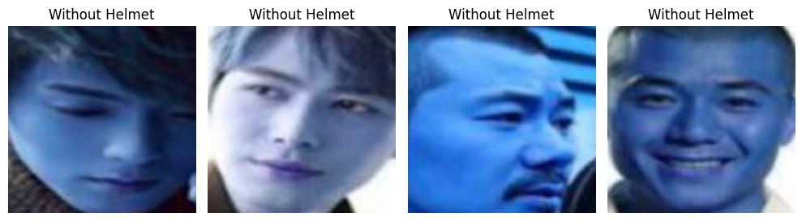

```python
import matplotlib.pyplot as plt

def plot_random_images(images, labels, class_label, class_name, n=4):
    indices = np.where(labels == class_label)[0]
    selected = np.random.choice(indices, n, replace=False)

    plt.figure(figsize=(10, 3))
    for i, idx in enumerate(selected):
        plt.subplot(1, n, i+1)
        plt.imshow(images[idx])
        plt.title(class_name)
        plt.axis('off')
    plt.tight_layout()
    plt.show()

# Plot for each class
plot_random_images(images, labels['Label'].values, 1, "With Helmet")
plot_random_images(images, labels['Label'].values, 0, "Without Helmet")
```

# Check for Class Imbalance

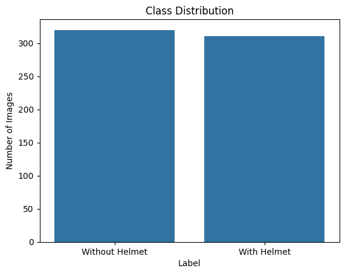

```
Class counts:
 Label
0    320
1    311
Name: count, dtype: int64
```

```python
import seaborn as sns

sns.countplot(x=labels['Label'])
plt.title("Class Distribution")
plt.xticks([0, 1], ['Without Helmet', 'With Helmet'])
plt.ylabel("Number of Images")
plt.show()

# Print exact counts
label_counts = labels['Label'].value_counts()
print("Class counts:\n", label_counts)
```

Observation:

With Helmet: 311 images

Without Helmet: 320 images

The classes are almost balanced, which is ideal for binary classification.

- The dataset is balanced with nearly equal number of images in both classes.
- Images show workers in varied postures and actions, captured under different lighting and backgrounds—this improves model generalization.
- Both classes (helmeted and non-helmeted) have good visual diversity, indicating the dataset is realistic and suitable for training a robust model.
- No missing values or corrupted images observed at this stage.

# Convert RGB Images to Grayscale

```python
import cv2

# Convert RGB to Grayscale
images_gray = np.array([cv2.cvtColor(img, cv2.COLOR_RGB2GRAY) for img in images])

# Reshape to add channel dimension (needed for CNNs)
images_gray = images_gray.reshape(-1, 200, 200, 1)
```

# Plot Images Before and After Preprocessing

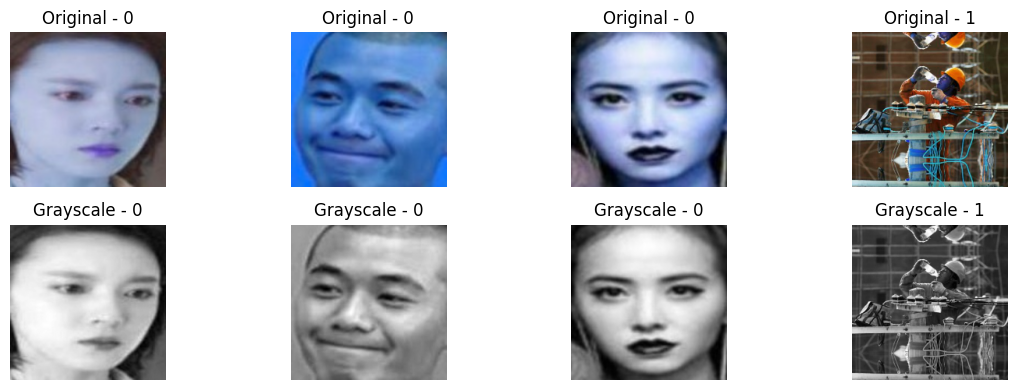

```python
def compare_preprocessing(rgb_images, gray_images, labels, n=4):
    plt.figure(figsize=(12, 4))
    for i in range(n):
        idx = np.random.randint(0, len(rgb_images))

        # RGB image
        plt.subplot(2, n, i+1)
        plt.imshow(rgb_images[idx])
        plt.title(f"Original - {labels[idx]}")
        plt.axis('off')

        # Grayscale image
        plt.subplot(2, n, n+i+1)
        plt.imshow(gray_images[idx].reshape(200, 200), cmap='gray')
        plt.title(f"Grayscale - {labels[idx]}")
        plt.axis('off')
    plt.tight_layout()
    plt.show()

compare_preprocessing(images, images_gray, labels['Label'].values)
```

# Train, Validation & Test Split

```python
from sklearn.model_selection import train_test_split

# First split into train (70%) and temp (30%)
X_train, X_temp, y_train, y_temp = train_test_split(
    images_gray, labels['Label'].values, test_size=0.3, stratify=labels['Label'].values, random_state=42)

# Split temp into validation (15%) and test (15%)
X_val, X_test, y_val, y_test = train_test_split(
    X_temp, y_temp, test_size=0.5, stratify=y_temp, random_state=42)

print(f"Train: {X_train.shape}, Val: {X_val.shape}, Test: {X_test.shape}")
```

```
Train: (441, 200, 200, 1), Val: (95, 200, 200, 1), Test: (95, 200, 200, 1)
```

# Normalize the Images

```python
X_train = X_train / 255.0
X_val = X_val / 255.0
X_test = X_test / 255.0
```

```python
# Convert all training and validation data to the correct NumPy format
X_train = np.array(X_train)
X_val = np.array(X_val)
y_train = np.array(y_train).astype('float32')
y_val = np.array(y_val).astype('float32')
```

# Define the CNN Model

```python
from tensorflow.keras.models import Sequential
from tensorflow.keras.layers import Conv2D, MaxPooling2D, Flatten, Dense, Dropout

model = Sequential([
    Conv2D(32, (3, 3), activation='relu', input_shape=(200, 200, 1)),
    MaxPooling2D(2, 2),

    Conv2D(64, (3, 3), activation='relu'),
    MaxPooling2D(2, 2),

    Flatten(),
    Dense(128, activation='relu'),
    Dropout(0.5),
    Dense(1, activation='sigmoid')
])
```

# Utility Function

```python
# defining a function to compute different metrics to check performance of a classification model built using statsmodels
def model_performance_classification(model, predictors, target):
    """
    Function to compute different metrics to check classification model performance

    model: classifier
    predictors: independent variables
    target: dependent variable
    """

    # checking which probabilities are greater than threshold
    pred = model.predict(predictors).reshape(-1)>0.5

    target = target.to_numpy().reshape(-1)


    acc = accuracy_score(target, pred)  # to compute Accuracy
    recall = recall_score(target, pred, average='weighted')  # to compute Recall
    precision = precision_score(target, pred, average='weighted')  # to compute Precision
    f1 = f1_score(target, pred, average='weighted')  # to compute F1-score

    # creating a dataframe of metrics
    df_perf = pd.DataFrame({"Accuracy": acc, "Recall": recall, "Precision": precision, "F1 Score": f1,},index=[0],)

    return df_perf
```

```python
def plot_confusion_matrix(model,predictors,target,ml=False):
    """
    Function to plot the confusion matrix

    model: classifier
    predictors: independent variables
    target: dependent variable
    ml: To specify if the model used is an sklearn ML model or not (True means ML model)
    """

    # checking which probabilities are greater than threshold
    pred = model.predict(predictors).reshape(-1)>0.5

    target = target.to_numpy().reshape(-1)

    # Plotting the Confusion Matrix using confusion matrix() function which is also predefined tensorflow module
    confusion_matrix = tf.math.confusion_matrix(target,pred)
    f, ax = plt.subplots(figsize=(10, 8))
    sns.heatmap(
        confusion_matrix,
        annot=True,
        linewidths=.4,
        fmt="d",
        square=True,
        ax=ax
    )
    plt.show()
```

# Define the Configuration

```python
model.compile(
    loss='binary_crossentropy',
    optimizer='adam',
    metrics=['accuracy']
)
```

# Convert Your Images to Grayscale

```python
import cv2
import numpy as np

# Convert your RGB image dataset to grayscale
images_gray = np.array([cv2.cvtColor(img, cv2.COLOR_RGB2GRAY) for img in images])

# Reshape to add channel dimension (important for CNN)
images_gray = images_gray.reshape(-1, 200, 200, 1)
```

# Train-Test Split

```python
from sklearn.model_selection import train_test_split

X_train, X_temp, y_train, y_temp = train_test_split(
    images_gray, labels['Label'].values, test_size=0.3, stratify=labels['Label'].values, random_state=42)

X_val, X_test, y_val, y_test = train_test_split(
    X_temp, y_temp, test_size=0.5, stratify=y_temp, random_state=42)
```

# Array Type Conversion

```python
X_train = np.array(X_train)
X_val = np.array(X_val)
y_train = np.array(y_train).astype('float32')
y_val = np.array(y_val).astype('float32')
```

```python
# Set training parameters
epochs = 15
batch_size = 32
history = model.fit(
    X_train, y_train,
    validation_data=(X_val, y_val),
    epochs=epochs,
    batch_size=batch_size,
    verbose=1)
```

```
14/14 ━━━━━━━━━━━━━━━━━━━━ 14s 502ms/step - accuracy: 0.5793 - loss: 203.8742 - val_accuracy: 0.9684 - val_loss: 2.9750
14/14 ━━━━━━━━━━━━━━━━━━━━ 9s 38ms/step - accuracy: 0.9749 - loss: 1.5461 - val_accuracy: 0.9789 - val_loss: 2.9118
14/14 ━━━━━━━━━━━━━━━━━━━━ 1s 36ms/step - accuracy: 0.9930 - loss: 0.2077 - val_accuracy: 0.9895 - val_loss: 3.1425
14/14 ━━━━━━━━━━━━━━━━━━━━ 0s 34ms/step - accuracy: 0.9896 - loss: 0.3995 - val_accuracy: 0.9789 - val_loss: 2.7221
14/14 ━━━━━━━━━━━━━━━━━━━━ 1s 34ms/step - accuracy: 0.9966 - loss: 0.0231 - val_accuracy: 0.9895 - val_loss: 3.7360
14/14 ━━━━━━━━━━━━━━━━━━━━ 0s 34ms/step - accuracy: 1.0000 - loss: 1.0841e-04 - val_accuracy: 0.9789 - val_loss: 2.6550
14/14 ━━━━━━━━━━━━━━━━━━━━ 1s 34ms/step - accuracy: 0.9974 - loss: 0.0200 - val_accuracy: 0.9789 - val_loss: 2.5132
14/14 ━━━━━━━━━━━━━━━━━━━━ 1s 36ms/step - accuracy: 1.0000 - loss: 4.1784e-12 - val_accuracy: 0.9684 - val_loss: 2.4754
14/14 ━━━━━━━━━━━━━━━━━━━━ 1s 34ms/step - accuracy: 1.0000 - loss: 7.0282e-09 - val_accuracy: 0.9684 - val_loss: 2.4828
14/14 ━━━━━━━━━━━━━━━━━━━━ 0s 34ms/step - accuracy: 1.0000 - loss: 5.0109e-11 - val_accuracy: 0.9684 - val_loss: 2.4856
14/14 ━━━━━━━━━━━━━━━━━━━━ 0s 34ms/step - accuracy: 0.9992 - loss: 0.0015 - val_accuracy: 0.9684 - val_loss: 2.4881
14/14 ━━━━━━━━━━━━━━━━━━━━ 1s 36ms/step - accuracy: 1.0000 - loss: 1.9847e-09 - val_accuracy: 0.9684 - val_loss: 2.4916
14/14 ━━━━━━━━━━━━━━━━━━━━ 0s 34ms/step - accuracy: 0.9960 - loss: 0.0942 - val_accuracy: 0.9895 - val_loss: 2.7890
14/14 ━━━━━━━━━━━━━━━━━━━━ 0s 34ms/step - accuracy: 0.9933 - loss: 0.3660 - val_accuracy: 0.9579 - val_loss: 5.6523
14/14 ━━━━━━━━━━━━━━━━━━━━ 1s 34ms/step - accuracy: 0.9834 - loss: 0.4171 - val_accuracy: 0.9895 - val_loss: 2.0672
```

# Import VGG-16 Base Model

```python
from tensorflow.keras.applications import VGG16
from tensorflow.keras.models import Model
from tensorflow.keras.layers import Flatten, Dense, Dropout, Input
from tensorflow.keras.optimizers import Adam
```

# Define the Model

```python
# Convert grayscale (1-channel) to RGB (3-channel)
X_train_vgg = np.repeat(X_train, 3, axis=-1)
X_val_vgg = np.repeat(X_val, 3, axis=-1)

# Define base model (without top classifier layers)
vgg_base = VGG16(weights='imagenet', include_top=False, input_shape=(200, 200, 3))

# Freeze the base layers
for layer in vgg_base.layers:
    layer.trainable = False

# Add custom classifier on top
x = vgg_base.output
x = Flatten()(x)
x = Dense(128, activation='relu')(x)
x = Dropout(0.5)(x)
predictions = Dense(1, activation='sigmoid')(x)

# Final model
vgg_model = Model(inputs=vgg_base.input, outputs=predictions)
```

```
Downloading data from https://storage.googleapis.com/tensorflow/keras-applications/vgg16/vgg16_weights_tf_dim_ordering_tf_kernels_notop.h5
58889256/58889256 ━━━━━━━━━━━━━━━━━━━━ 0s 0us/step
```

# Compile the Model

```python
vgg_model.compile(
    loss='binary_crossentropy',
    optimizer=Adam(learning_rate=0.0001),
    metrics=['accuracy']
)
```

# Train the Model

```python
history_vgg = vgg_model.fit(
    X_train_vgg, y_train,
    validation_data=(X_val_vgg, y_val),
    epochs=15,
    batch_size=32,
    verbose=1
)
```

```
14/14 ━━━━━━━━━━━━━━━━━━━━ 40s 2s/step - accuracy: 0.8023 - loss: 2.9507 - val_accuracy: 0.9895 - val_loss: 0.0444
14/14 ━━━━━━━━━━━━━━━━━━━━ 6s 160ms/step - accuracy: 0.9969 - loss: 0.0331 - val_accuracy: 1.0000 - val_loss: 3.2771e-06
14/14 ━━━━━━━━━━━━━━━━━━━━ 2s 158ms/step - accuracy: 1.0000 - loss: 1.0833e-08 - val_accuracy: 1.0000 - val_loss: 2.3583e-05
14/14 ━━━━━━━━━━━━━━━━━━━━ 2s 135ms/step - accuracy: 1.0000 - loss: 6.0195e-07 - val_accuracy: 1.0000 - val_loss: 5.2339e-05
14/14 ━━━━━━━━━━━━━━━━━━━━ 3s 135ms/step - accuracy: 1.0000 - loss: 5.2367e-08 - val_accuracy: 1.0000 - val_loss: 3.3113e-05
14/14 ━━━━━━━━━━━━━━━━━━━━ 2s 158ms/step - accuracy: 1.0000 - loss: 6.7936e-11 - val_accuracy: 1.0000 - val_loss: 2.8764e-05
14/14 ━━━━━━━━━━━━━━━━━━━━ 2s 137ms/step - accuracy: 0.9987 - loss: 0.0369 - val_accuracy: 1.0000 - val_loss: 2.5460e-06
14/14 ━━━━━━━━━━━━━━━━━━━━ 2s 160ms/step - accuracy: 1.0000 - loss: 1.4781e-07 - val_accuracy: 1.0000 - val_loss: 1.7321e-04
14/14 ━━━━━━━━━━━━━━━━━━━━ 2s 137ms/step - accuracy: 1.0000 - loss: 1.1215e-06 - val_accuracy: 1.0000 - val_loss: 3.6955e-04
14/14 ━━━━━━━━━━━━━━━━━━━━ 2s 137ms/step - accuracy: 1.0000 - loss: 4.9838e-05 - val_accuracy: 1.0000 - val_loss: 5.1584e-04
14/14 ━━━━━━━━━━━━━━━━━━━━ 3s 137ms/step - accuracy: 1.0000 - loss: 7.3681e-05 - val_accuracy: 1.0000 - val_loss: 1.6322e-04
14/14 ━━━━━━━━━━━━━━━━━━━━ 2s 138ms/step - accuracy: 1.0000 - loss: 3.6756e-06 - val_accuracy: 1.0000 - val_loss: 1.2107e-04
14/14 ━━━━━━━━━━━━━━━━━━━━ 3s 139ms/step - accuracy: 1.0000 - loss: 8.8975e-09 - val_accuracy: 1.0000 - val_loss: 1.1207e-04
14/14 ━━━━━━━━━━━━━━━━━━━━ 3s 141ms/step - accuracy: 1.0000 - loss: 1.6395e-08 - val_accuracy: 1.0000 - val_loss: 1.0853e-04
14/14 ━━━━━━━━━━━━━━━━━━━━ 2s 162ms/step - accuracy: 1.0000 - loss: 1.4433e-08 - val_accuracy: 1.0000 - val_loss: 1.0606e-04
```

# Performance Summary

```python
val_loss, val_acc = vgg_model.evaluate(X_val_vgg, y_val, verbose=0)
print(f"Validation Accuracy: {val_acc:.4f}")
```

```
Validation Accuracy: 1.0000
```

# Observation

# Convert Grayscale to RGB

```python
# VGG-16 expects 3-channel input
X_train_vgg = np.repeat(X_train, 3, axis=-1)
X_val_vgg = np.repeat(X_val, 3, axis=-1)
```

# Load Pre-trained VGG-16 Model

```python
from tensorflow.keras.applications import VGG16
from tensorflow.keras.models import Model
from tensorflow.keras.layers import Input

# Load VGG16 without classifier layers (include_top=False)
vgg_model = VGG16(weights='imagenet', include_top=False, input_shape=(200, 200, 3))

# Freeze the convolutional base
for layer in vgg_model.layers:
    layer.trainable = False
```

# Extract Features from VGG16

```python
# Extract features from train and validation sets
X_train_features = vgg_model.predict(X_train_vgg)
X_val_features = vgg_model.predict(X_val_vgg)

# Flatten feature maps to use as input for FFNN
X_train_flat = X_train_features.reshape(X_train_features.shape[0], -1)
X_val_flat = X_val_features.reshape(X_val_features.shape[0], -1)
```

```
14/14 ━━━━━━━━━━━━━━━━━━━━ 2s 131ms/step
3/3 ━━━━━━━━━━━━━━━━━━━━ 1s 211ms/step
```

# Define the FFNN Classifier

```python
from tensorflow.keras.models import Sequential
from tensorflow.keras.layers import Dense, Dropout

ffnn = Sequential([
    Dense(256, activation='relu', input_shape=(X_train_flat.shape[1],)),
    Dropout(0.5),
    Dense(128, activation='relu'),
    Dropout(0.3),
    Dense(1, activation='sigmoid')
])
```

# Compile the Model

```python
ffnn.compile(
    loss='binary_crossentropy',
    optimizer='adam',
    metrics=['accuracy']
)
```

# Train the FFNN Model

```python
history_ffnn = ffnn.fit(
    X_train_flat, y_train,
    validation_data=(X_val_flat, y_val),
    epochs=15,
    batch_size=32,
    verbose=1
)
```

```
14/14 ━━━━━━━━━━━━━━━━━━━━ 5s 181ms/step - accuracy: 0.8667 - loss: 1.3688 - val_accuracy: 1.0000 - val_loss: 2.0879e-16
14/14 ━━━━━━━━━━━━━━━━━━━━ 0s 8ms/step - accuracy: 0.9962 - loss: 0.0255 - val_accuracy: 1.0000 - val_loss: 1.3060e-26
14/14 ━━━━━━━━━━━━━━━━━━━━ 0s 9ms/step - accuracy: 1.0000 - loss: 1.5930e-06 - val_accuracy: 1.0000 - val_loss: 1.2252e-26
14/14 ━━━━━━━━━━━━━━━━━━━━ 0s 8ms/step - accuracy: 0.9994 - loss: 0.0091 - val_accuracy: 1.0000 - val_loss: 9.5513e-33
14/14 ━━━━━━━━━━━━━━━━━━━━ 0s 8ms/step - accuracy: 0.9981 - loss: 0.0681 - val_accuracy: 1.0000 - val_loss: 0.0000e+00
14/14 ━━━━━━━━━━━━━━━━━━━━ 0s 8ms/step - accuracy: 1.0000 - loss: 1.8675e-11 - val_accuracy: 1.0000 - val_loss: 4.6050e-27
14/14 ━━━━━━━━━━━━━━━━━━━━ 0s 11ms/step - accuracy: 0.9931 - loss: 0.0056 - val_accuracy: 1.0000 - val_loss: 0.0000e+00
14/14 ━━━━━━━━━━━━━━━━━━━━ 0s 9ms/step - accuracy: 1.0000 - loss: 1.4677e-25 - val_accuracy: 1.0000 - val_loss: 0.0000e+00
14/14 ━━━━━━━━━━━━━━━━━━━━ 0s 8ms/step - accuracy: 1.0000 - loss: 2.9047e-17 - val_accuracy: 1.0000 - val_loss: 0.0000e+00
14/14 ━━━━━━━━━━━━━━━━━━━━ 0s 8ms/step - accuracy: 1.0000 - loss: 2.2154e-36 - val_accuracy: 1.0000 - val_loss: 0.0000e+00
14/14 ━━━━━━━━━━━━━━━━━━━━ 0s 8ms/step - accuracy: 1.0000 - loss: 4.6979e-14 - val_accuracy: 1.0000 - val_loss: 0.0000e+00
14/14 ━━━━━━━━━━━━━━━━━━━━ 0s 8ms/step - accuracy: 1.0000 - loss: 9.1964e-35 - val_accuracy: 1.0000 - val_loss: 0.0000e+00
14/14 ━━━━━━━━━━━━━━━━━━━━ 0s 11ms/step - accuracy: 1.0000 - loss: 3.5993e-13 - val_accuracy: 1.0000 - val_loss: 0.0000e+00
14/14 ━━━━━━━━━━━━━━━━━━━━ 0s 8ms/step - accuracy: 1.0000 - loss: 1.1308e-17 - val_accuracy: 1.0000 - val_loss: 0.0000e+00
14/14 ━━━━━━━━━━━━━━━━━━━━ 0s 9ms/step - accuracy: 1.0000 - loss: 1.1731e-29 - val_accuracy: 1.0000 - val_loss: 0.0000e+00
```

# validation acccuracy

```python
val_loss, val_acc = ffnn.evaluate(X_val_flat, y_val, verbose=0)
print(f"Validation Accuracy: {val_acc:.4f}")
```

```
Validation Accuracy: 1.0000
```

# Observation

## The VGG-16 with FFNN model achieved a perfect validation accuracy of 100%, indicating that the feature extraction from VGG-16 combined with a custom fully connected neural network was highly effective. This architecture leveraged powerful pre-trained features while allowing flexibility in classification through the FFNN.However, as with any perfect score, it raises the possibility of overfitting—especially if the validation set is small or similar to the training data. Further testing on a separate, unseen test set is advisable to ensure the model generalizes well.

# Data Augmentation Setup

```python
from tensorflow.keras.preprocessing.image import ImageDataGenerator

# ImageDataGenerator with augmentation
train_aug = ImageDataGenerator(
    rotation_range=20,
    width_shift_range=0.1,
    height_shift_range=0.1,
    zoom_range=0.2,
    horizontal_flip=True
)

# For validation, we only rescale
val_aug = ImageDataGenerator()

# Prepare generators
train_gen = train_aug.flow(X_train_vgg, y_train, batch_size=32)
val_gen = val_aug.flow(X_val_vgg, y_val, batch_size=32)
```

# Define VGG-16 Model

```python
from tensorflow.keras.applications import VGG16
from tensorflow.keras.models import Model
from tensorflow.keras.layers import Flatten, Dense, Dropout
from tensorflow.keras.optimizers import Adam

# Load pre-trained VGG-16
vgg_base = VGG16(weights='imagenet', include_top=False, input_shape=(200, 200, 3))

# Freeze base layers
for layer in vgg_base.layers:
    layer.trainable = False

# Add custom classifier
x = vgg_base.output
x = Flatten()(x)
x = Dense(128, activation='relu')(x)
x = Dropout(0.5)(x)
output = Dense(1, activation='sigmoid')(x)

vgg_aug_model = Model(inputs=vgg_base.input, outputs=output)
```

# Compile the model

```python
vgg_aug_model.compile(
    loss='binary_crossentropy',
    optimizer=Adam(learning_rate=0.0001),
    metrics=['accuracy']
)
```